# STAT501_L78_Drill_Analysis

Ada Lazuli

2025-10-26

```r
library(dplyr)
library(ggplot2)
library(qqplotr)
library(tidyr)
library(reactable)
library(openxlsx)
library(nortest) # For anderson-darling test
library(lmtest) # needed for Breusch-Pagan test
```

# Drill Data Analysis

## Data and Background

A laboratory that tests consumer products selected a variety of drills to compare how likely each will overheat under certain conditions.

The response variable for analysis is **AVTEM** = mean temperature of drill. The dataset includes predictor variables measuring factors to control the drill’s resistance to overheating.

In particular, **IT** is thickness of insulation, **QW** is an assessment of wire quality in the drill motor, **VS** is the size of the vent used in the drill motor, **I2** is **IT** centered and squared, and **Q2** is **QW** centered and squared.

```r
df <- read.csv("~/Downloads/HW6Drill.csv")
head(df)
```

```
##   AVTEM IT I2 VS QW Q2
## 1   161  5  1 11  6  1
## 2   185  2  4 10  8  1
## 3   145  6  4 12  6  1
## 4   167  3  1 11  8  1
## 5   154  4  0 12  7  0
## 6   154  5  1 12  6  1
```

## Modeling

```r
model <- lm(AVTEM ~ IT + I2 + VS + QW + Q2, data = df)
summary(model)
```

```
##
## Call:
## lm(formula = AVTEM ~ IT + I2 + VS + QW + Q2, data = df)
##
## Residuals:
##    Min     1Q Median     3Q    Max
## -9.575 -2.876  0.454  2.600  9.158
##
## Coefficients:
##             Estimate Std. Error t value Pr(>|t|)
## (Intercept) 233.8587     6.8442  34.169  < 2e-16 ***
## IT           -6.1500     0.2959 -20.781  < 2e-16 ***
## I2            1.0040     0.2501   4.014 0.000129 ***
## VS           -3.9167     0.5126  -7.641 3.16e-11 ***
## QW           -0.5500     0.5126  -1.073 0.286348
## Q2           -0.1167     0.8878  -0.131 0.895767
## ---
## Signif. codes:  0 '***' 0.001 '**' 0.01 '*' 0.05 '.' 0.1 ' ' 1
##
## Residual standard error: 3.97 on 84 degrees of freedom
## Multiple R-squared:  0.858,  Adjusted R-squared:  0.8495
## F-statistic: 101.5 on 5 and 84 DF,  p-value: < 2.2e-16
```

```r
anova(model)
```

```
## Analysis of Variance Table
##
## Response: AVTEM
##           Df Sum Sq Mean Sq  F value    Pr(>F)
## IT         1 6808.0  6808.0 431.8559 < 2.2e-16 ***
## I2         1  254.0   254.0  16.1123 0.0001292 ***
## VS         1  920.4   920.4  58.3849 3.158e-11 ***
## QW         1   18.2    18.2   1.1513 0.2863477
## Q2         1    0.3     0.3   0.0173 0.8957673
## Residuals 84 1324.2    15.8
## ---
## Signif. codes:  0 '***' 0.001 '**' 0.01 '*' 0.05 '.' 0.1 ' ' 1
```

Based on the ANOVA output, the sum of squared errors is 1324.2 with degrees of freedom 84

## Analysis of QW and Q2

We need to perform a general linear F-test to determine whether QW and Q2 provide significant information about the response.

$H_0: QW=Q2= 0 \\ H_a: (QW \neq 0) \vee (Q2 \neq 0)$

$$F^* = \frac{\frac{SSE_R - SSE_F}{P_F - P_R}}{\frac{SSE_F}{n - P_F}}$$
$$SSE_R = 1324.2 + 0.3 + 18.2 = 1342.7, \quad P_F = 6,\quad P_R = 4, \quad
SSE_F = 1324.2$$
So,

$$F^* = \frac{(1342.7-1324.2)/(6-4)}{1324.2/84} = 0.5868$$

Then, to get the **p-value**,

```r
1 - pf(0.5868, 2, 84)
```

```
## [1] 0.5583671
```

At a significance level of 5%, there is not evidence that QW and Q2 contribute significantly after considering the rest of the predictors.

## LINE Assumption Verification On Reducted Model

```r
model <- lm(AVTEM ~ IT + I2 + VS, data = df)
df$resid <- resid(model)
df$fitted <- fitted(model)
summary(model)
```

```
##
## Call:
## lm(formula = AVTEM ~ IT + I2 + VS, data = df)
##
## Residuals:
##      Min       1Q   Median       3Q      Max
## -10.1643  -2.4641   0.6337   2.5198   9.6690
##
## Coefficients:
##             Estimate Std. Error t value Pr(>|t|)
## (Intercept) 229.9310     5.7701  39.849  < 2e-16 ***
## IT           -6.1500     0.2945 -20.882  < 2e-16 ***
## I2            1.0040     0.2489   4.034 0.000119 ***
## VS           -3.9167     0.5101  -7.678 2.36e-11 ***
## ---
## Signif. codes:  0 '***' 0.001 '**' 0.01 '*' 0.05 '.' 0.1 ' ' 1
##
## Residual standard error: 3.951 on 86 degrees of freedom
## Multiple R-squared:  0.856,  Adjusted R-squared:  0.851
## F-statistic: 170.4 on 3 and 86 DF,  p-value: < 2.2e-16
```

```r
anova(model)
```

```
## Analysis of Variance Table
##
## Response: AVTEM
##           Df Sum Sq Mean Sq F value    Pr(>F)
## IT         1 6808.0  6808.0 436.072 < 2.2e-16 ***
## I2         1  254.0   254.0  16.270 0.0001185 ***
## VS         1  920.4   920.4  58.955 2.357e-11 ***
## Residuals 86 1342.7    15.6
## ---
## Signif. codes:  0 '***' 0.001 '**' 0.01 '*' 0.05 '.' 0.1 ' ' 1
```

### Normalcy

Starting with the assumption or normalcy.

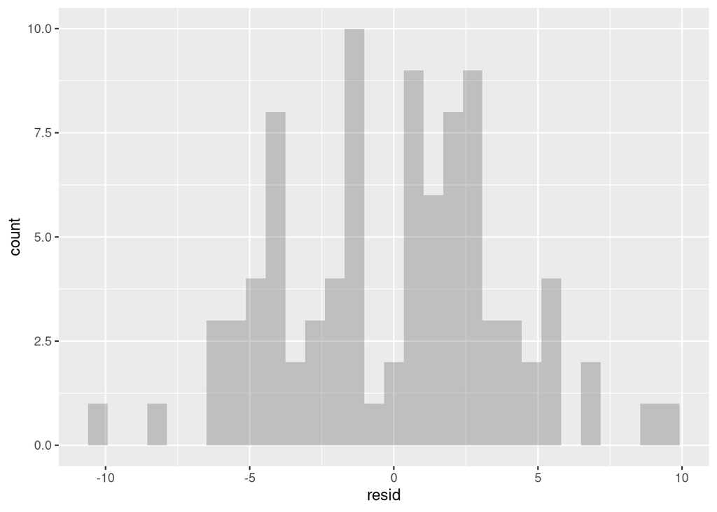

```r
ggplot(df, aes(x=resid)) + geom_histogram(alpha=0.3)
```

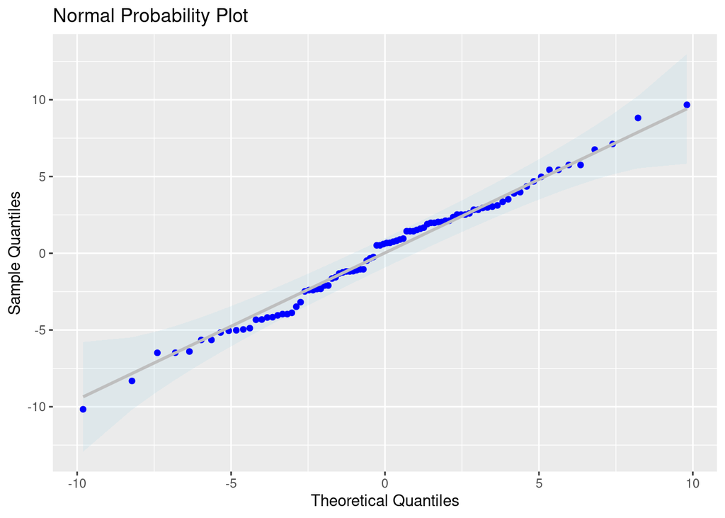

```r
ggplot(df, aes(sample = resid)) +
  stat_qq_band(distribution = "norm", alpha = 0.2, fill = "lightblue") +
  stat_qq_point(distribution = "norm", color = "blue") +
  stat_qq_line(distribution = "norm", color = "grey", size = 1) +
  labs(title = "Normal Probability Plot",
       x = "Theoretical Quantiles",
       y = "Sample Quantiles")
```

Based on the probability plot and histogram, it seems like the residuals are approximately normally distributed.

The Anderson-Darling test will allow for confirmation.

$H_0: \text{The errors follow a normal distribution}\\ H_a: \text{The errors do not follow a normal distribution}$

```r
ad.test(df$resid)
```

```
##
##  Anderson-Darling normality test
##
## data:  df$resid
## A = 0.43939, p-value = 0.2866
```

With a $\text{p-value} = 0.2866$, there is not enough evidence to reject the null hypothesis.

### Linearity and Equal Variance

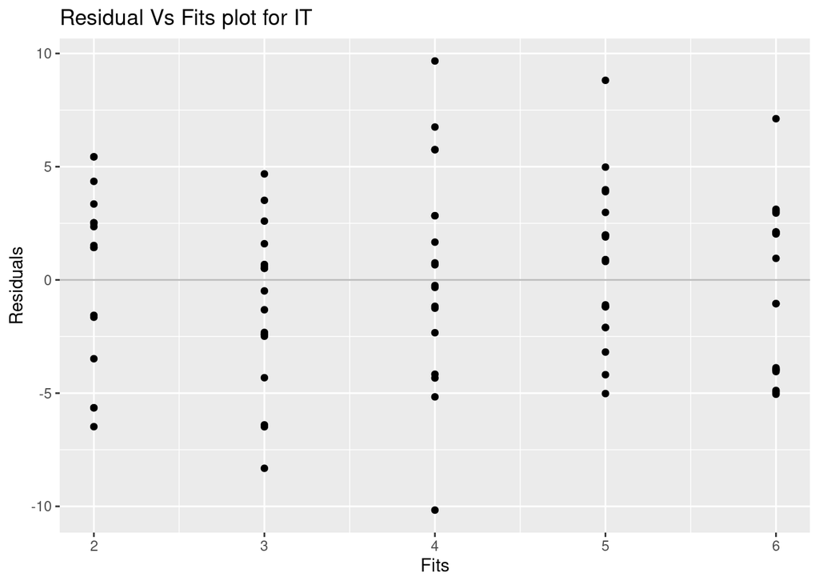

```r
ggplot(df, aes(x = IT, y=resid)) + geom_point() + ylab("Residuals") + xlab("Fits") + ggtitle("Residual Vs Fits plot for IT") +  geom_hline(yintercept = 0, color = "grey")
```

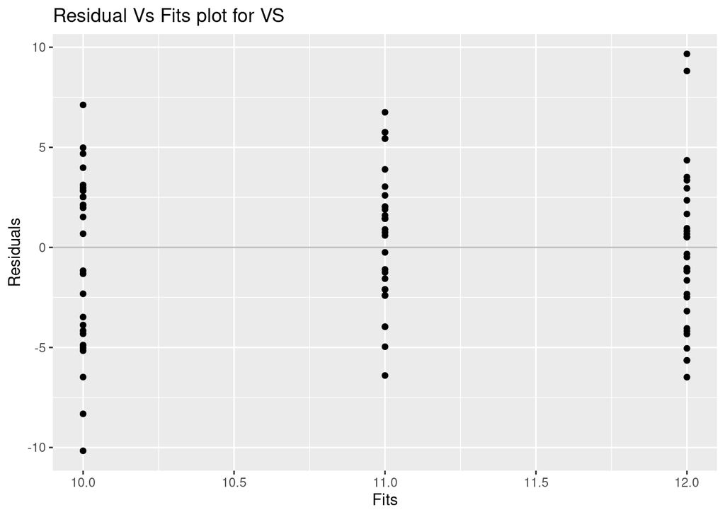

```r
ggplot(df, aes(x = VS, y=resid)) + geom_point() + ylab("Residuals") + xlab("Fits") + ggtitle("Residual Vs Fits plot for VS") +  geom_hline(yintercept = 0, color = "grey")
```

Based on the scatter plots, it seems that the assumptions for linearity and equal variance are met.

Going further with a a **Breusch-Pagan** test for equal variance:

#### Manual BP Test

```r
df$e <- resid(model)
df$e2 <- df$e^2
```

```r
aux <- lm(e2 ~ IT + I2 + VS, data = df)
anova(aux)
```

```
## Analysis of Variance Table
##
## Response: e2
##           Df Sum Sq Mean Sq F value Pr(>F)
## IT         1      9    8.70  0.0217 0.8832
## I2         1    356  356.07  0.8881 0.3486
## VS         1    171  171.20  0.4270 0.5152
## Residuals 86  34480  400.93
```

$H_0: \forall_{i \in \{1,2,3\}} \gamma_i = 0\\H_a: \exists_{i \in \{1,2,3\}} \gamma_i \neq 0$

Our test statistic is given by

$$\chi^2_{bp} = \frac{SSR^*}{2} \div \Bigg(\frac{SSE_F}{n}\Bigg)^2$$
Where our degrees of freedom are based on the number of predictors. In this case $df = 3$. **Note:** There is some conflicting information on whether to divide the $SSR^*$ term by 2 when conducting MLR.

$$SSR^* = 9 + 356 + 171 = 536, \quad SSE_F = 1342.7, \quad n=90, \quad
df = 3$$

So,

$$\chi^2_{bp} = \frac{SSR^*}{2} \div \Bigg(\frac{SSE_F}{n}\Bigg)^2 =
\frac{536}{2} \div \Bigg(\frac{1342.7}{90}\Bigg)^2 = 1.20$$

The critical region for this test is:

```r
qchisq(0.95,3)
```

```
## [1] 7.814728
```

And our p-value is:

```r
1 - pchisq(1.204098,3)
```

```
## [1] 0.7520216
```

So we fail to reject the null hypothesis.

At a significance level of 5%, there no evidence that the constancy of residuals differ from 0 for each of the predictors.

#### Using lmtest package

```r
bptest(model, ~ IT + I2 + VS, data = df)
```

```
##
##  studentized Breusch-Pagan test
##
## data:  model
## BP = 1.3776, df = 3, p-value = 0.7108
```

### Confidence and Prediction Intervals

We need to perform a confidence interval for drills with the characteristics of: 1. $IT = 6$ 2. $I2 = 4$ 3. $VS = 10$

```r
new <- data.frame(IT = 6, I2 = 4, VS = 10)

predict(model, newdata = new, interval = "confidence", level = 0.95)
```

```
##        fit      lwr      upr
## 1 157.8802 155.8642 159.8961
```

```r
new <- data.frame(IT = 6, I2 = 4, VS = 10)

predict(model, newdata = new, interval = "prediction", level = 0.95)
```

```
##        fit      lwr      upr
## 1 157.8802 149.7708 165.9895
```